# Practical Machine Learning Course Project

Bahman S

September 25, 2016

## Introduction

This document is the practical machine learning course project for the Coursera Data Sience specialization. In this project, your goal will be to use data from accelerometers on the belt, forearm, arm, and dumbell of 6 participants. The goal of this project is to predict the manner in which they did the exercise. We describe how the model is built, how cross validation is used, and what is the expected out of sample error. We will also use our prediction model to predict 20 different test cases.

## Loading the libraries and downloading the data

We clear the global environment and load the required libraries.

```r
rm(list = ls())
library(data.table)
library(caret)
```

```r
library(ggplot2)
library(rattle)
library(rpart)
library(rpart.plot)
```

Here we download the data and load it to training and testing data frames. We also set seed.

```r
train_url <- 'https://d396qusza40orc.cloudfront.net/predmachlearn/pml-training.csv'
test_url <- 'https://d396qusza40orc.cloudfront.net/predmachlearn/pml-testing.csv'
training <- fread(train_url)
testing <- fread(test_url)
set.seed(100)
```

## Cleaning the data

```r
missing_training <- as.data.table(t(training[, lapply(.SD, function(x) sum(is.na(x) | x == "", na.rm = TRUE))]), keep.rownames = TRUE)
table(missing_training$V1)
```

```
##
##     0 19216
##    60   100
```

```r
missing <- missing_training[V1 != 0, rn]
training <- training[, setdiff(names(training), missing), with = FALSE]
testing <- testing[, setdiff(names(testing), missing), with = FALSE]

training <- as.data.frame(training)
testing <- as.data.frame(testing)
```

## Data partitioning

We partition the training dataset to 70% training and 30% validate datasets.

```r
inTrain <- createDataPartition(y = training$classe, p = 0.7, list = FALSE)
training <- training[inTrain,]
validate <- training[-inTrain,]
```

## Further cleaning the data

Now we identify the near-zero variance variables. The outcome depends very little on these variables.

```r
nsv <- nearZeroVar(training, saveMetrics = TRUE)
nsv <- nsv[order(-nsv$freqRatio),]
head(nsv)
```

```
##               freqRatio percentUnique zeroVar   nzv
## pitch_arm      75.93548   20.23003567   FALSE FALSE
## pitch_forearm  61.95455   19.07257771   FALSE FALSE
## roll_arm       52.28889   17.70401107   FALSE FALSE
## new_window     45.72449    0.01455922   FALSE  TRUE
## yaw_arm        30.96053   19.12353498   FALSE FALSE
## yaw_forearm    14.65591   12.79027444   FALSE FALSE
```

“new_window” is the only variable with near-zero variance, so we remove it:

```r
training <- training[,setdiff(names(training),"new_window")]
validate <- validate[,setdiff(names(validate), "new_window")]
testing <- testing[,setdiff(names(testing), "new_window")]
```

We also remove unrelated variables V1 and “user_name”, window and time stamp values:

```r
training <- training[, setdiff(names(training), c(grep("time|window", names(training), value = TRUE), "V1", "user_name"))]
validate <- validate[, setdiff(names(validate), c(grep("time|window", names(validate), value = TRUE), "V1", "user_name"))]
testing <- testing[, setdiff(names(testing), c(grep("time|window", names(testing), value = TRUE), "V1", "user_name"))]
```

## Modeling

We fix the class of data:

```r
training$classe <- as.factor(training$classe)
validate$classe <- as.factor(validate$classe)
```

### Regression tree

We create a model using rpart (regression tree), and plot it:

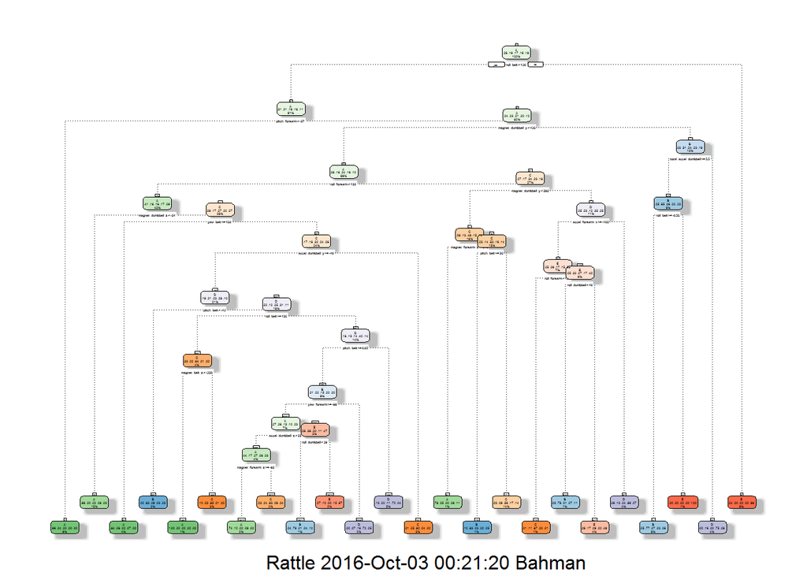

```r
treefit <- rpart(classe ~ ., data = training, method = "class")
fancyRpartPlot(treefit)
```

And we “validate”" the model:

```r
treepredict <- predict(treefit, validate, type = "class")
confusionMatrix(treepredict, validate$classe)
```

```
## Confusion Matrix and Statistics
##
##           Reference
## Prediction    A    B    C    D    E
##          A 1023  175    8   69   23
##          B   30  473   35   20   43
##          C   35   72  608  107   95
##          D   46   47   47  407   41
##          E   28   36   13   55  588
##
## Overall Statistics
##
##                Accuracy : 0.7515
##                  95% CI : (0.738, 0.7646)
##     No Information Rate : 0.2818
##     P-Value [Acc > NIR] : < 2.2e-16
##
##                   Kappa : 0.6848
##  Mcnemar's Test P-Value : < 2.2e-16
##
## Statistics by Class:
##
##                      Class: A Class: B Class: C Class: D Class: E
## Sensitivity            0.8804   0.5890   0.8551  0.61854   0.7443
## Specificity            0.9072   0.9615   0.9095  0.94778   0.9604
## Pos Pred Value         0.7881   0.7870   0.6630  0.69218   0.8167
## Neg Pred Value         0.9508   0.9063   0.9679  0.92902   0.9407
## Prevalence             0.2818   0.1947   0.1724  0.15955   0.1916
## Detection Rate         0.2481   0.1147   0.1474  0.09869   0.1426
## Detection Prevalence   0.3147   0.1457   0.2224  0.14258   0.1746
## Balanced Accuracy      0.8938   0.7752   0.8823  0.78316   0.8524
```

Now, we run the 20 test cases through the classification and regression tree:

```r
treeresult <- predict(treefit, testing[, setdiff(names(testing), c("problem_id"))], type = "class")
treeresult
```

```
##  1  2  3  4  5  6  7  8  9 10 11 12 13 14 15 16 17 18 19 20
##  B  A  A  D  A  C  D  A  A  A  C  E  C  A  E  E  A  A  A  B
## Levels: A B C D E
```

### Random forest

We develop a random forest model with 5-fold cross validation and 250 bootstrap samples:

```r
rfcontrol <- trainControl(method = "cv", 5)
rffit <- train(classe ~ ., data = training, method = "rf", trControl = rfcontrol, ntree = 250)
rffit
```

```
## Random Forest
##
## 13737 samples
##    52 predictor
##     5 classes: 'A', 'B', 'C', 'D', 'E'
##
## No pre-processing
## Resampling: Cross-Validated (5 fold)
## Summary of sample sizes: 10989, 10991, 10988, 10990, 10990
## Resampling results across tuning parameters:
##
##   mtry  Accuracy   Kappa
##    2    0.9904639  0.9879364
##   27    0.9901000  0.9874768
##   52    0.9828935  0.9783566
##
## Accuracy was used to select the optimal model using  the largest value.
## The final value used for the model was mtry = 2.
```

and we “validate” the model on the validate dataset:

```r
rfpredict <- predict(rffit, validate)
confusionMatrix(validate$classe, rfpredict)
```

```
## Confusion Matrix and Statistics
##
##           Reference
## Prediction    A    B    C    D    E
##          A 1162    0    0    0    0
##          B    0  803    0    0    0
##          C    0    0  711    0    0
##          D    0    0    0  658    0
##          E    0    0    0    0  790
##
## Overall Statistics
##
##                Accuracy : 1
##                  95% CI : (0.9991, 1)
##     No Information Rate : 0.2818
##     P-Value [Acc > NIR] : < 2.2e-16
##
##                   Kappa : 1
##  Mcnemar's Test P-Value : NA
##
## Statistics by Class:
##
##                      Class: A Class: B Class: C Class: D Class: E
## Sensitivity            1.0000   1.0000   1.0000   1.0000   1.0000
## Specificity            1.0000   1.0000   1.0000   1.0000   1.0000
## Pos Pred Value         1.0000   1.0000   1.0000   1.0000   1.0000
## Neg Pred Value         1.0000   1.0000   1.0000   1.0000   1.0000
## Prevalence             0.2818   0.1947   0.1724   0.1596   0.1916
## Detection Rate         0.2818   0.1947   0.1724   0.1596   0.1916
## Detection Prevalence   0.2818   0.1947   0.1724   0.1596   0.1916
## Balanced Accuracy      1.0000   1.0000   1.0000   1.0000   1.0000
```

```r
rfresult <- predict(rffit, testing[, setdiff(names(testing), c("problem_id"))])
rfresult
```

```
##  [1] B A B A A E D B A A B C B A E E A B B B
## Levels: A B C D E
```